# ME114 Day 5: Solutions for Assignment 5

Ken Benoit and Slava Mikhaylov

## Exercise 5.1

Logistic regression may be used to predict the probability of `default` using `income` and `balance` on the Default dataset. Here we will estimate the test error of this logistic regression model using the validation set approach. Do not forget to set a random seed before beginning your analysis.

```r
library(ISLR)
summary(Default)
```

```
##  default    student       balance           income
##  No :9667   No :7056   Min.   :   0.0   Min.   :  772
##  Yes: 333   Yes:2944   1st Qu.: 481.7   1st Qu.:21340
##                        Median : 823.6   Median :34553
##                        Mean   : 835.4   Mean   :33517
##                        3rd Qu.:1166.3   3rd Qu.:43808
##                        Max.   :2654.3   Max.   :73554
```

1. Fit a logistic regression model that uses `income` and `balance` to predict `default`.

```r
set.seed(1)
glm.fit <-  glm(default ~ income + balance, data = Default, family = binomial)
```

2. Using the validation set approach, estimate the test error of this model. In order to do this, you must perform the following steps:
   1. Split the sample set into a training set and a validation set.
   2. Fit a multiple logistic regression model using only the training observations.
   3. Obtain a prediction of default status for each individual in the validation set by computing the posterior probability of default for that individual, and classifying the individual to the `default` category if the posterior probability is greater than 0.5.
   4. Compute the validation set error, which is the fraction of the observations in the validation set that are misclassified.

```r
Q5 = function() {
    # i.
    train <-  sample(dim(Default)[1], dim(Default)[1]/2)
    # ii.
    glm.fit <-  glm(default ~ income + balance, data = Default, family = binomial,
        subset = train)
    # iii.
    glm.pred <-  rep("No", dim(Default)[1]/2)
    glm.probs <-  predict(glm.fit, Default[-train, ], type = "response")
    glm.pred[glm.probs > 0.5] <-  "Yes"
    # iv.
    return(mean(glm.pred != Default[-train, ]$default))
}
Q5()
```

```
## [1] 0.0286
```

**2.86% test error rate from validation set approach.**

3. Repeat the process in (b) three times, using three different splits of the observations into a training set and a validation set. Comment on the results obtained.

```r
Q5()
```

```
## [1] 0.0236
```

```r
Q5()
```

```
## [1] 0.028
```

```r
Q5()
```

```
## [1] 0.0268
```

**Average around 2.6% test error rate.**

4. Now consider a logistic regression model that predicts the probability of `default` using `income`, `balance`, and a dummy variable for `student`. Estimate the test error for this model using the validation set approach. Comment on whether or not including a dummy variable for `student` leads to a reduction in the test error rate.

```r
train <-  sample(dim(Default)[1], dim(Default)[1]/2)
glm.fit <-  glm(default ~ income + balance + student, data = Default, family = binomial, subset = train)
glm.pred <-  rep("No", dim(Default)[1]/2)
glm.probs <-  predict(glm.fit, Default[-train, ], type = "response")
glm.pred[glm.probs > 0.5] <-  "Yes"
mean(glm.pred != Default[-train, ]$default)
```

```
## [1] 0.0264
```

**2.64% test error rate, with student dummy variable. Using the validation set approach, it doesn’t appear adding the student dummy variable leads to a reduction in the test error rate.**

## Exercise 5.2

We consider the use of a logistic regression model to predict the probability of `default` using `income` and `balance` on the Default dataset. In particular, we will now compute estimates for the standard errors of the `income` and `balance` logistic regression coefficients in two different ways: (1) using the bootstrap, and (2) using the standard formula for computing the standard errors in the [glm()](http://bit.ly/R_glm) function. Do not forget to set a random seed before beginning your analysis.

1. Using the [summary()](http://bit.ly/R_summary) and [glm()](http://bit.ly/R_glm) functions, determine the estimated standard errors for the coefficients associated with income and balance in a multiple logistic regression model that uses both predictors.

```r
set.seed(1)
glm.fit <-  glm(default~income+balance, data=Default, family=binomial)
summary(glm.fit)
```

```
##
## Call:
## glm(formula = default ~ income + balance, family = binomial,
##     data = Default)
##
## Deviance Residuals:
##     Min       1Q   Median       3Q      Max
## -2.4725  -0.1444  -0.0574  -0.0211   3.7245
##
## Coefficients:
##               Estimate Std. Error z value Pr(>|z|)
## (Intercept) -1.154e+01  4.348e-01 -26.545  < 2e-16 ***
## income       2.081e-05  4.985e-06   4.174 2.99e-05 ***
## balance      5.647e-03  2.274e-04  24.836  < 2e-16 ***
## ---
## Signif. codes:  0 '***' 0.001 '**' 0.01 '*' 0.05 '.' 0.1 ' ' 1
##
## (Dispersion parameter for binomial family taken to be 1)
##
##     Null deviance: 2920.6  on 9999  degrees of freedom
## Residual deviance: 1579.0  on 9997  degrees of freedom
## AIC: 1585
##
## Number of Fisher Scoring iterations: 8
```

2. Write a function, `boot.fn()`, that takes as input the Default data set as well as an index of the observations, and that outputs the coefficient estimates for `income` and `balance` in the multiple logistic regression model.

```r
boot.fn <-  function(data, index)
  return(coef(glm(default ~ income + balance, data = data, family = binomial, subset = index)))
```

3. Use the [boot()](http://bit.ly/R_boot) function together with your `boot.fn()` function to estimate the standard errors of the logistic regression coefficients for `income` and `balance`.

```r
library(boot)
boot(Default, boot.fn, 50)
```

```
##
## ORDINARY NONPARAMETRIC BOOTSTRAP
##
##
## Call:
## boot(data = Default, statistic = boot.fn, R = 50)
##
##
## Bootstrap Statistics :
##          original        bias     std. error
## t1* -1.154047e+01  1.181200e-01 4.202402e-01
## t2*  2.080898e-05 -5.466926e-08 4.542214e-06
## t3*  5.647103e-03 -6.974834e-05 2.282819e-04
```

4. Comment on the estimated standard errors obtained using the [glm()](http://bit.ly/R_glm) function and using your bootstrap function.

**Very similar results.**

## Exercise 5.3

In Sections 5.3.2 and 5.3.3 in James et al (2013), it is shown that [cv.glm()](http://bit.ly/R_cv_glm) function can be used to compute the LOOCV test error estimate. Alternatively, one could compute those quantities using just the [glm()](http://bit.ly/R_glm) and `predict.glm()` functions, and a [for()](http://bit.ly/R_Control) loop. You will now use this approach to compute the LOOCV error for a simple logistic regression model on the Weekly dataset. Recall how the LOOCV error is covered in the context of classification problems.

```r
summary(Weekly)
```

```
##       Year           Lag1               Lag2               Lag3
##  Min.   :1990   Min.   :-18.1950   Min.   :-18.1950   Min.   :-18.1950
##  1st Qu.:1995   1st Qu.: -1.1540   1st Qu.: -1.1540   1st Qu.: -1.1580
##  Median :2000   Median :  0.2410   Median :  0.2410   Median :  0.2410
##  Mean   :2000   Mean   :  0.1506   Mean   :  0.1511   Mean   :  0.1472
##  3rd Qu.:2005   3rd Qu.:  1.4050   3rd Qu.:  1.4090   3rd Qu.:  1.4090
##  Max.   :2010   Max.   : 12.0260   Max.   : 12.0260   Max.   : 12.0260
##       Lag4               Lag5              Volume
##  Min.   :-18.1950   Min.   :-18.1950   Min.   :0.08747
##  1st Qu.: -1.1580   1st Qu.: -1.1660   1st Qu.:0.33202
##  Median :  0.2380   Median :  0.2340   Median :1.00268
##  Mean   :  0.1458   Mean   :  0.1399   Mean   :1.57462
##  3rd Qu.:  1.4090   3rd Qu.:  1.4050   3rd Qu.:2.05373
##  Max.   : 12.0260   Max.   : 12.0260   Max.   :9.32821
##      Today          Direction
##  Min.   :-18.1950   Down:484
##  1st Qu.: -1.1540   Up  :605
##  Median :  0.2410
##  Mean   :  0.1499
##  3rd Qu.:  1.4050
##  Max.   : 12.0260
```

```r
set.seed(1)
```

1. Fit a logistic regression model that predicts `Direction` using `Lag1` and `Lag2`.

```r
glm.fit <-  glm(Direction ~ Lag1 + Lag2, data = Weekly, family = binomial)
summary(glm.fit)
```

```
##
## Call:
## glm(formula = Direction ~ Lag1 + Lag2, family = binomial, data = Weekly)
##
## Deviance Residuals:
##    Min      1Q  Median      3Q     Max
## -1.623  -1.261   1.001   1.083   1.506
##
## Coefficients:
##             Estimate Std. Error z value Pr(>|z|)
## (Intercept)  0.22122    0.06147   3.599 0.000319 ***
## Lag1        -0.03872    0.02622  -1.477 0.139672
## Lag2         0.06025    0.02655   2.270 0.023232 *
## ---
## Signif. codes:  0 '***' 0.001 '**' 0.01 '*' 0.05 '.' 0.1 ' ' 1
##
## (Dispersion parameter for binomial family taken to be 1)
##
##     Null deviance: 1496.2  on 1088  degrees of freedom
## Residual deviance: 1488.2  on 1086  degrees of freedom
## AIC: 1494.2
##
## Number of Fisher Scoring iterations: 4
```

2. Fit a logistic regression model that predicts `Direction` using `Lag1` and `Lag2` *using all but the first observation*.

```r
glm.fit <-  glm(Direction ~ Lag1 + Lag2, data = Weekly[-1,], family = binomial)
summary(glm.fit)
```

```
##
## Call:
## glm(formula = Direction ~ Lag1 + Lag2, family = binomial, data = Weekly[-1,
##     ])
##
## Deviance Residuals:
##     Min       1Q   Median       3Q      Max
## -1.6258  -1.2617   0.9999   1.0819   1.5071
##
## Coefficients:
##             Estimate Std. Error z value Pr(>|z|)
## (Intercept)  0.22324    0.06150   3.630 0.000283 ***
## Lag1        -0.03843    0.02622  -1.466 0.142683
## Lag2         0.06085    0.02656   2.291 0.021971 *
## ---
## Signif. codes:  0 '***' 0.001 '**' 0.01 '*' 0.05 '.' 0.1 ' ' 1
##
## (Dispersion parameter for binomial family taken to be 1)
##
##     Null deviance: 1494.6  on 1087  degrees of freedom
## Residual deviance: 1486.5  on 1085  degrees of freedom
## AIC: 1492.5
##
## Number of Fisher Scoring iterations: 4
```

3. Use the model from (b) to predict the direction of the first observation. You can do this by predicting that the first observation will go up if `P(Direction="Up"|Lag1, Lag2)` > 0.5. Was this observation correctly classified?

```r
predict.glm(glm.fit, Weekly[1,], type="response") > 0.5
```

```
##    1
## TRUE
```

**Prediction was UP, true Direction was DOWN.**

4. Write a for loop from $i=1$ to $i=n$ ,where $n$ is the number of observations in the data set, that performs each of the following steps:
   1. Fit a logistic regression model using all but the $i$th observation to predict `Direction` using `Lag1` and `Lag2`.
   2. Compute the posterior probability of the market moving up for the $i$th observation.
   3. Use the posterior probability for the $i$th observation in order to predict whether or not the market moves up.
   4. Determine whether or not an error was made in predicting the direction for the $i$th observation. If an error was made, then indicate this as a 1, and otherwise indicate it as a 0.

```r
count <-  rep(0, dim(Weekly)[1])
for (i in 1:(dim(Weekly)[1])) {
  glm.fit <-  glm(Direction ~ Lag1 + Lag2, data = Weekly[-i,], family = binomial)
  is_up <-  predict.glm(glm.fit, Weekly[i,], type = "response") > 0.5
  is_true_up <-  Weekly[i,]$Direction == "Up"
  if (is_up != is_true_up)
    count[i] = 1
}
sum(count)
```

```
## [1] 490
```

**490 errors.**

5. Take the average of the $n$ numbers obtained in (d)iv in order to obtain the LOOCV estimate for the test error. Comment on the results.

```r
mean(count)
```

```
## [1] 0.4499541
```

**LOOCV estimates a test error rate of 45%.**

## Exercise 5.4

We will now perform cross-validation on a simulated data set.

1. Generate a simulated data set as follows:

```r
   set.seed(1)
   y <- rnorm(100)
   x <- rnorm(100)
   y <- x-2*x^2+rnorm(100)
```

In this data set, what is $n$ and what is $p$? Write out the model used to generate the data in equation form.

**n = 100, p = 2.**

**$Y = X - 2 X^2 + \epsilon$.**

2. Create a scatterplot of $X$ against $Y$. Comment on what you find.

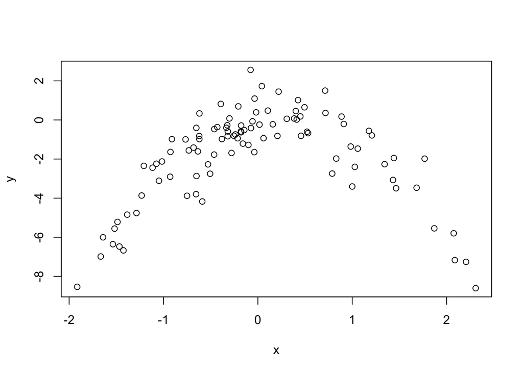

```r
plot(x, y)
```

**Quadratic plot. $X$ from about -2 to 2. $Y$ from about -8 to 2.**

3. Set a random seed, and then compute the LOOCV errors that result from fitting the following four models using least squares:
1. $Y = \beta_0 + \beta_1 X + \epsilon$
2. $Y = \beta_0 + \beta_1 X + \beta_2 X_2 + \epsilon$
3. $Y = \beta_0 + \beta_1 X + \beta_2 X_2 + \beta_3 X_3 + \epsilon$
4. $Y = \beta_0 + \beta_1 X + \beta_2 X_2 + \beta_3 X_3 + \beta_4 X_4 + \epsilon$.

*Note: you may find it helpful to use the `data.frame()` function to create a single data set containing both $X$ and $Y$.*

```r
library(boot)
Data <-  data.frame(x,y)
set.seed(1)

# 1.
glm.fit <-  glm(y~x)
cv.glm(Data, glm.fit)$delta
```

```
## [1] 5.890979 5.888812
```

```r
# 2.
glm.fit <-  glm(y~poly(x,2))
cv.glm(Data, glm.fit)$delta
```

```
## [1] 1.086596 1.086326
```

```r
# 3.
glm.fit <-  glm(y~poly(x,3))
cv.glm(Data, glm.fit)$delta
```

```
## [1] 1.102585 1.102227
```

```r
# 4.
glm.fit <-  glm(y~poly(x,4))
cv.glm(Data, glm.fit)$delta
```

```
## [1] 1.114772 1.114334
```

4. Repeat (c) using another random seed, and report your results. Are your results the same as what you got in (c)? Why?

```r
set.seed(10)

# 1
glm.fit <-  glm(y~x)
cv.glm(Data, glm.fit)$delta
```

```
## [1] 5.890979 5.888812
```

```r
# 2
glm.fit <-  glm(y~poly(x,2))
cv.glm(Data, glm.fit)$delta
```

```
## [1] 1.086596 1.086326
```

```r
# 3
glm.fit <-  glm(y~poly(x,3))
cv.glm(Data, glm.fit)$delta
```

```
## [1] 1.102585 1.102227
```

```r
# 4
glm.fit <-  glm(y~poly(x,4))
cv.glm(Data, glm.fit)$delta
```

```
## [1] 1.114772 1.114334
```

**Exact same, LOOCV is not randomly splitting into training and test, and cycles through all observations.**

5. Which of the models in (c) had the smallest LOOCV error? Is this what you expected? Explain your answer.

**The quadratic polynomial had the lowest LOOCV test error rate. This was expected because it matches the true form of $Y$.**

6. Comment on the statistical significance of the coefficient estimates that results from fitting each of the models in (c) using least squares. Do these results agree with the conclusions drawn based on the cross-validation results?

```r
summary(glm.fit)
```

```
##
## Call:
## glm(formula = y ~ poly(x, 4))
##
## Deviance Residuals:
##     Min       1Q   Median       3Q      Max
## -2.8914  -0.5244   0.0749   0.5932   2.7796
##
## Coefficients:
##             Estimate Std. Error t value Pr(>|t|)
## (Intercept)  -1.8277     0.1041 -17.549   <2e-16 ***
## poly(x, 4)1   2.3164     1.0415   2.224   0.0285 *
## poly(x, 4)2 -21.0586     1.0415 -20.220   <2e-16 ***
## poly(x, 4)3  -0.3048     1.0415  -0.293   0.7704
## poly(x, 4)4  -0.4926     1.0415  -0.473   0.6373
## ---
## Signif. codes:  0 '***' 0.001 '**' 0.01 '*' 0.05 '.' 0.1 ' ' 1
##
## (Dispersion parameter for gaussian family taken to be 1.084654)
##
##     Null deviance: 552.21  on 99  degrees of freedom
## Residual deviance: 103.04  on 95  degrees of freedom
## AIC: 298.78
##
## Number of Fisher Scoring iterations: 2
```

**p-values show statistical significance of linear and quadratic terms, which agrees with the CV results.**